# HubertBanieckiPd1

Hubert Baniecki

6 03 2019

# 1 Wstęp

W tej pracy domowej przejrzę dataset zakupów zrobionych w serwisie Allegro podczas jednego dnia. Najpierw zobaczę czym charakteryzuje się cały zbiór danych oraz poszczególne zmienne. Dalej poszukam zależności pomiędzy zmiennymi oraz innych ciekawych obserwacji. W tym zadaniu, poza pakietami **dplyr** i **ggplot2**, użyję pakietów **visdat**, **funModeling** oraz **DataExplorer**.

# 2 Dane

Na dane składa się ponad 420 tysięcy zakupów.  
Każdy z nich opisany jest przez 14 zmiennych: 5 dyskretnych oraz 9 ciągłych.  
W całym zbiorze danych nie ma żadnych brakujących wartości.  
Wyróżniającymi się zmiennymi są `data` oraz `lp`, czyli unikalny id zakupu. Możemy go dalej pominąć.

```r
kable_styling(kable(t(as.matrix(introduce(data))), col.names="", format = "html"), bootstrap_options = "striped", full_width = F)
```

| rows | 420020 |
| --- | --- |
| columns | 14 |
| discrete_columns | 5 |
| continuous_columns | 9 |
| all_missing_columns | 0 |
| total_missing_values | 0 |
| complete_rows | 420020 |
| total_observations | 5880280 |
| memory_usage | 52321224 |

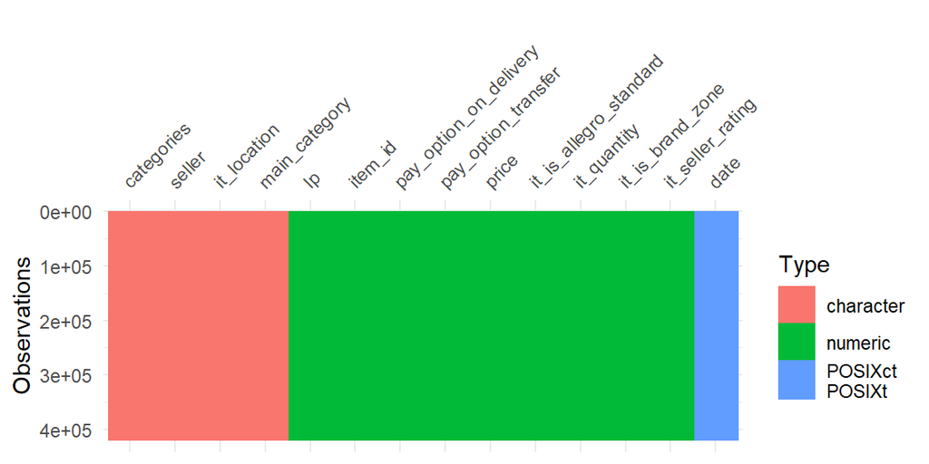

```r
vis_dat(data, warn_large_data=FALSE, palette = "default")
```

```r
isTRUE(length(data$lp)==dim(data)[1])
```

```
## [1] TRUE
```

```r
data <- select(data, -lp)
```

# 3 Zmienne

## 3.1 date

Pierwszą interesującą zmienną w zbiorze danych jest `date`. Jak możemy zauważyć, dane pochodzą z jednego pełnego dnia.  
Widać bardzo mało transakcji w nocy, stałą ilość w trakcie dnia oraz zaskakujący wzrost do godziny 21.  
Ciężko stwierdzić co może powodować mało zakupów o 22 oraz bardzo dużo zakupów o 23.

```r
kable_styling(kable(t(as.matrix(as.character(summary(data$date))))), bootstrap_options = "striped", full_width = F)
```

| Min. | 1st Qu. | Median | Mean | 3rd Qu. | Max. |
| --- | --- | --- | --- | --- | --- |
| 2016-04-03 00:00:09 | 2016-04-03 12:50:14 | 2016-04-03 17:12:25 | 2016-04-03 16:24:21 | 2016-04-03 20:14:39 | 2016-04-03 23:59:59 |

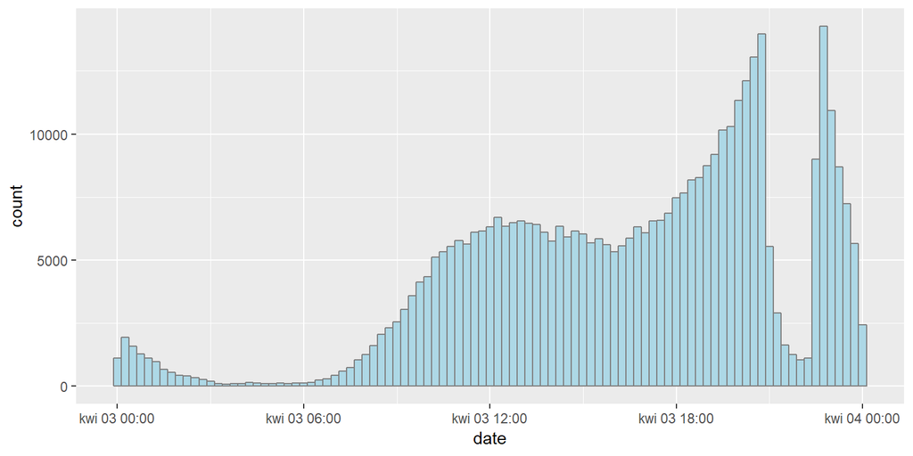

```r
ggplot(data, aes(x=as.POSIXct(data$date,format="%H:%M"))) +
    geom_histogram( fill="lightblue", binwidth = 15*60,color="grey50") + xlab("date")
```

## 3.2 categories i main_category

Zmienna `categories` przechowuje kilka kategorii dla każdego zakupu, a `main_category` to kategoria główna.  
Ogólnie kategorii jest 6758, a kategorii głównych 27. Każda z kategorii głównych pojawia się w kategoriach.  
Poniżej 27 najliczniejszych zliczonych kategorii oraz kategorii głównych.

```r
categoriesAll <- unlist(lapply(data$categories, function(x) unlist(strsplit(x,"'"))[c(FALSE,TRUE)]))
categoriesUnique <- unique(categoriesAll)
mainCategoriesUnique <- unique(data$main_category)
```

```r
length(categoriesUnique)
```

```
## [1] 6758
```

```r
length(mainCategoriesUnique)
```

```
## [1] 27
```

```r
all(mainCategoriesUnique %in% categoriesUnique)
```

```
## [1] TRUE
```

```r
categoriesCount <- arrange(as.data.frame(table(categoriesAll)), Freq)
categoriesCount$categoriesAll <- factor(categoriesCount$categoriesAll, levels=categoriesCount$categoriesAll)

mainCategoriesCount <- arrange(as.data.frame(table(data$main_category)), Freq)
mainCategoriesCount$Var1 <- factor(mainCategoriesCount$Var1, levels=mainCategoriesCount$Var1)
```

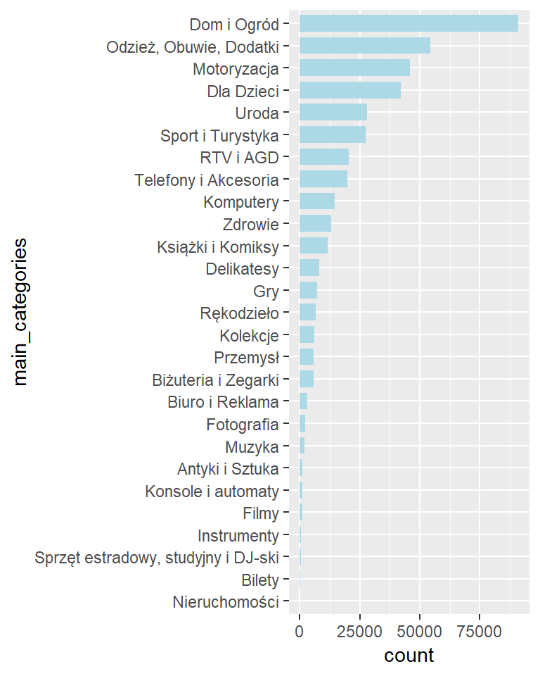

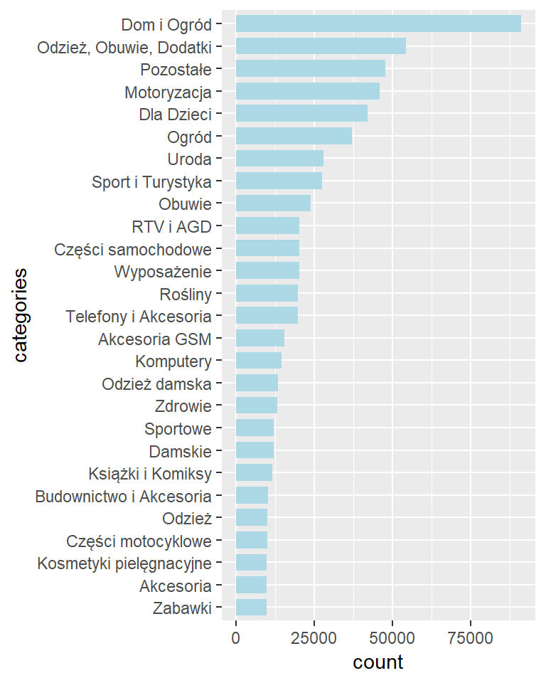

Wśród 27 najliczniejszych wyników dla obu grup powtarza się 11. Możemy je nazwać definitywnie najpopularniejszymi.

```r
temp <- mainCategoriesUnique %in% top_n(categoriesCount, 27, Freq)$categoriesAll
length(which(temp))
```

```
## [1] 11
```

```r
mainCategoriesUnique[temp]
```

```
##  [1] "Komputery"               "Odzież, Obuwie, Dodatki"
##  [3] "Dom i Ogród"             "Książki i Komiksy"
##  [5] "RTV i AGD"               "Motoryzacja"
##  [7] "Dla Dzieci"              "Uroda"
##  [9] "Telefony i Akcesoria"    "Sport i Turystyka"
## [11] "Zdrowie"
```

## 3.3 seller, it_location i item_id

Są to kolejne zmienne kategoryczne mające mocno skośne rozkłady.  
Możemy znaleźć najpopularniejsze produkty, sprzedawców lub ich lokalizacje.  
Zgodnie z oczekiwaniami, będą to największe miasta w Polsce oraz sklepy internetowe.

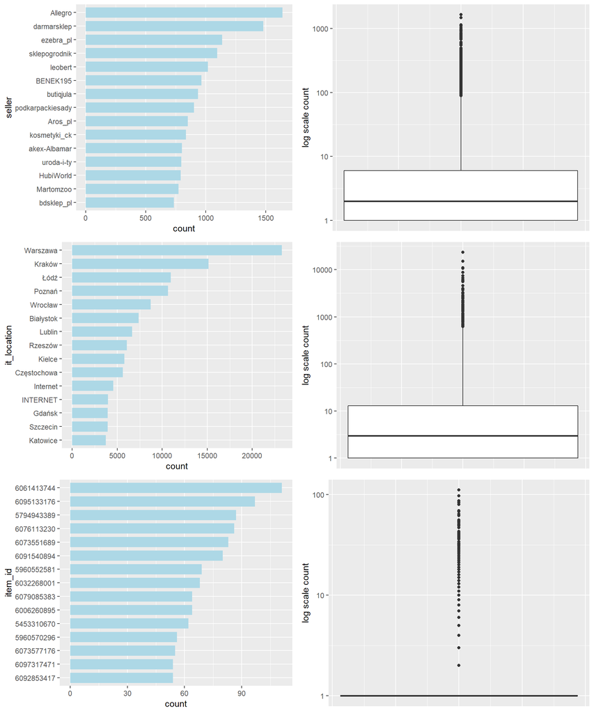

```r
seller <- arrange(as.data.frame(table(data$seller)), Freq)
seller$Var1 <- factor(seller$Var1, levels = seller$Var1)
plot11 <- ggplot(data = top_n(seller, 15, Freq), aes(x = Var1, y = Freq)) +
    geom_bar(stat = "identity", width = .75, fill="lightblue") + coord_flip() + xlab("seller") + ylab("count")

it_location <- arrange(as.data.frame(table(data$it_location)), Freq)
it_location$Var1 <- factor(it_location$Var1, levels = it_location$Var1)
plot21 <- ggplot(data = top_n(it_location, 15, Freq), aes(x = Var1, y = Freq)) +
    geom_bar(stat = "identity", width = .75, fill="lightblue") + coord_flip() + xlab("it_location") + ylab("count")

item_id  <- arrange(as.data.frame(table(data$item_id )), Freq)
item_id $Var1 <- factor(item_id $Var1, levels = item_id $Var1)
plot31 <- ggplot(data = top_n(item_id , 15, Freq), aes(x = Var1, y = Freq)) +
    geom_bar(stat = "identity", width = .75, fill="lightblue") + coord_flip() + xlab("item_id") + ylab("count")


seller <- as.data.frame(table(data$seller))$Freq
it_location <- as.data.frame(table(data$it_location))$Freq
item_id <- as.data.frame(table(data$item_id))$Freq

plot12 <- ggplot(data = NULL) + geom_boxplot(aes(y=seller)) + scale_y_log10() + ylab("log scale count") +
  theme(axis.title.x=element_blank(),
        axis.text.x=element_blank(),
        axis.ticks.x=element_blank())
plot22 <- ggplot(data = NULL) + geom_boxplot(aes(y=it_location)) + scale_y_log10() + ylab("log scale count") +
  theme(axis.title.x=element_blank(),
        axis.text.x=element_blank(),
        axis.ticks.x=element_blank())
plot32 <- ggplot(data = NULL) + geom_boxplot(aes(y=item_id)) + scale_y_log10() + ylab("log scale count") +
  theme(axis.title.x=element_blank(),
        axis.text.x=element_blank(),
        axis.ticks.x=element_blank())

grid.arrange(plot11, plot12, plot21, plot22, plot31, plot32, ncol=2,nrow=3)
```

## 3.4 Pozostałe zmienne kategoryczne

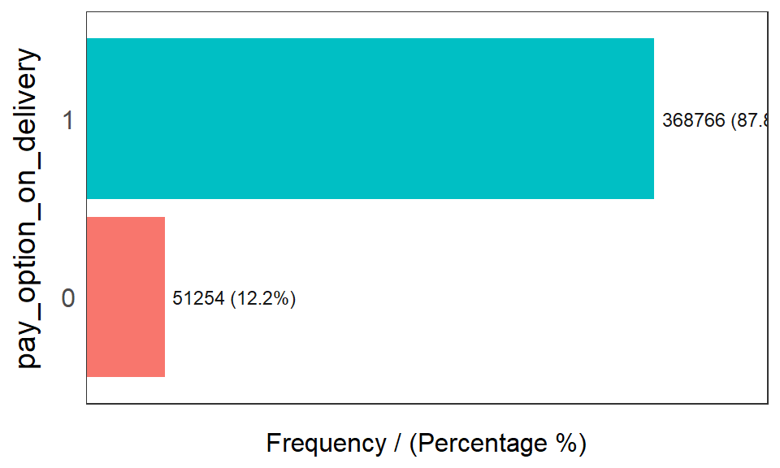

```
##   pay_option_on_delivery frequency percentage cumulative_perc
## 1                      1    368766       87.8            87.8
## 2                      0     51254       12.2           100.0
```

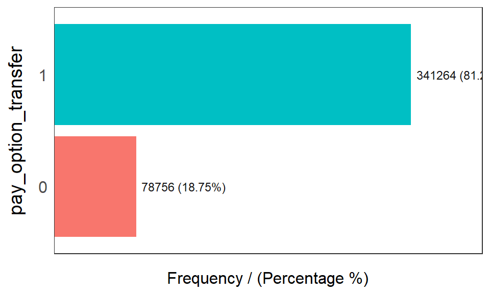

```
##   pay_option_transfer frequency percentage cumulative_perc
## 1                   1    341264      81.25           81.25
## 2                   0     78756      18.75          100.00
```

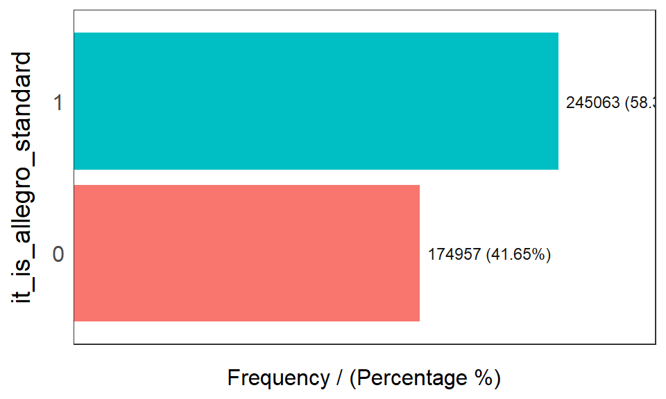

```
##   it_is_allegro_standard frequency percentage cumulative_perc
## 1                      1    245063      58.35           58.35
## 2                      0    174957      41.65          100.00
```

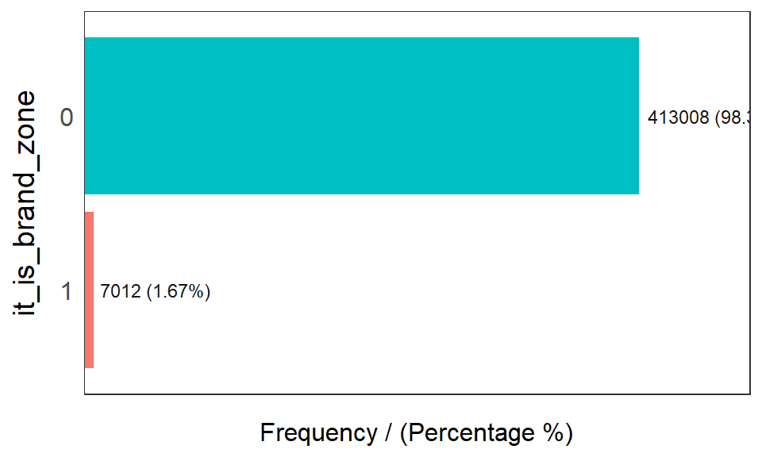

```
##   it_is_brand_zone frequency percentage cumulative_perc
## 1                0    413008      98.33           98.33
## 2                1      7012       1.67          100.00
```

```
## [1] "Variables processed: pay_option_on_delivery, pay_option_transfer, it_is_allegro_standard, it_is_brand_zone"
```

```r
a <- select(data, pay_option_on_delivery, pay_option_transfer, it_is_allegro_standard, it_is_brand_zone)
a$pay_option_on_delivery <- as.character(a$pay_option_on_delivery)
a$pay_option_transfer <- as.character(a$pay_option_transfer)
a$it_is_allegro_standard <- as.character(a$it_is_allegro_standard)
a$it_is_brand_zone <- as.character(a$it_is_brand_zone)
freq(a)
```

## 3.5 Pozostałe zmienne numeryczne

Dominują niskie ceny, chociaż coś kosztowało ponad 100 000 zł. Analiza wykazuje, że są to auta.  
Najwięcej sprzedawanych jest pojedyńczych sztuk produktów. Jest jakaś grupa produktów sprzedawana po 99 999 sztuk dziennie i nie ma ona konkretnej kategorii, lokalizacji, czy ceny. Sprzedają te produkty głównie duże sklepy.  
**Mogą to być oszuści, kupujący swoje produkty, żeby podbić ich pozycjonowanie w serwisie Allegro.**  
**Taka prawidłowość została zbadana na Amazonie już dawno.**  
Gęstość ratingu sprzedawców wydaje się być sensowna. Najlepszym sprzedawcom jest sklep x-kom.

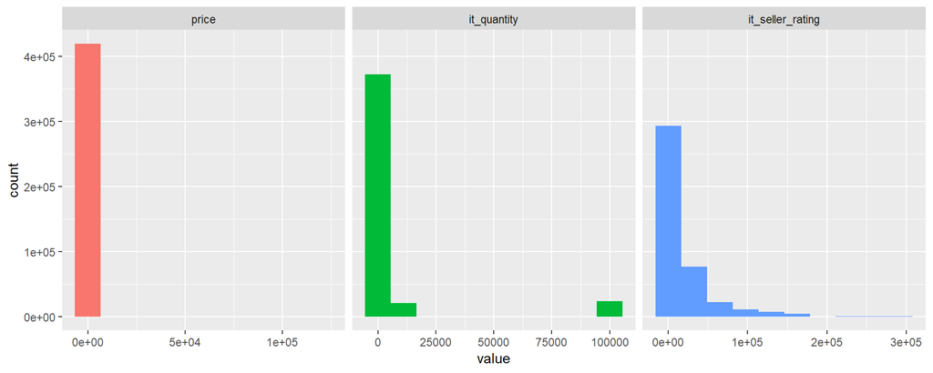

```r
b <- select(data, price, it_quantity, it_seller_rating)
plot_num(b, bins=10)
```

```r
x <- top_n(data,6,price)
y <- top_n(data,6,it_quantity)
z <- top_n(data,6,it_seller_rating)
x
```

| date | item_id | categories | pay_option_on_delivery | pay_option_transfer | seller | price | it_is_allegro_standard | it_quantity | it_is_brand_zone | it_seller_rating | it_location | main_category |
| --- | --- | --- | --- | --- | --- | --- | --- | --- | --- | --- | --- | --- |
| 2016-04-03 08:06:23 | 6080258883 | ['Motoryzacja', 'Samochody', 'Ciężarowe (pow. 3.5 t)', 'Ciągniki siodłowe', 'Ciągniki', 'MAN'] | 1 | 0 | POLTRANS-Matysek | 119000 | 0 | 0 | 0 | 9 | bodzentyn | Motoryzacja |
| 2016-04-03 23:10:54 | 6099875258 | ['Motoryzacja', 'Samochody', 'Osobowe', 'Honda', 'Civic', 'IX (2011-)'] | 1 | 0 | el_kocurro | 46000 | 0 | 0 | 0 | 171 | Gdańsk | Motoryzacja |
| 2016-04-03 14:16:44 | 6092152738 | ['Motoryzacja', 'Przyczepy, naczepy', 'Naczepy', 'Chłodnie'] | 1 | 0 | adamkac100 | 83000 | 0 | 0 | 0 | 85 | Ostrów Mazowiecka | Motoryzacja |
| 2016-04-03 17:22:34 | 6098088730 | ['Motoryzacja', 'Samochody', 'Ciężarowe (pow. 3.5 t)', 'Ciągniki siodłowe', 'Ciągniki', 'Volvo'] | 1 | 0 | iwka-2006 | 64900 | 0 | 0 | 0 | 1028 | Olawa | Motoryzacja |
| 2016-04-03 22:41:59 | 6099802337 | ['Motoryzacja', 'Samochody', 'Osobowe', 'Toyota', 'RAV4', 'III (2006-2012)'] | 1 | 1 | Kubota3 | 63900 | 0 | 0 | 0 | 12 | Warszawa | Motoryzacja |
| 2016-04-03 15:13:40 | 6097105898 | ['Motoryzacja', 'Samochody', 'Osobowe', 'Mercedes-Benz', 'ML', 'W164 (2005-2011)'] | 1 | 0 | zuzaziza | 52500 | 0 | 0 | 0 | 85 | WARSZAWA | Motoryzacja |
| 2016-04-03 15:28:48 | 6099019818 | ['Motoryzacja', 'Samochody', 'Ciężarowe (pow. 3.5 t)', 'Skrzynie z plandeką'] | 1 | 0 | LubieYangi | 46000 | 0 | 0 | 0 | 8 | łuków | Motoryzacja |

```r
head(y)
```

|  | date | item_id | categories | pay_option_on_delivery | pay_option_transfer | seller | price | it_is_allegro_standard | it_quantity | it_is_brand_zone | it_seller_rating | it_location | main_category |
| --- | --- | --- | --- | --- | --- | --- | --- | --- | --- | --- | --- | --- | --- |
| 1 | 2016-04-03 20:30:41 | 6053905674 | ['Dla Dzieci', 'Zabawki ogrodowe', 'Trampoliny'] | 1 | 1 | alleogrod1 | 409.00 | 1 | 99999 | 0 | 2506 | Nowy Targ | Dla Dzieci |
| 2 | 2016-04-03 17:45:28 | 6067599274 | ['Telefony i Akcesoria', 'Akcesoria GSM', 'Pokrowce, futerały, kabury', 'Futerały', 'LG'] | 1 | 1 | foreverKOM | 9.99 | 0 | 99999 | 0 | 2126 | Tylko wysyłka | Telefony i Akcesoria |
| 3 | 2016-04-03 14:34:32 | 6063751277 | ['Biżuteria i Zegarki', 'Biżuteria damska', 'Naszyjniki'] | 1 | 1 | Modern_Silver | 119.99 | 1 | 99999 | 0 | 11127 | Gdynia | Biżuteria i Zegarki |
| 4 | 2016-04-03 10:52:46 | 5918825276 | ['Sport i Turystyka', 'Sporty zimowe', 'Narciarstwo i snowboard', 'Odzież', 'Czapki'] | 1 | 1 | naszeprodukty-pl | 21.90 | 1 | 99999 | 0 | 5393 | ZELÓW | Sport i Turystyka |
| 5 | 2016-04-03 21:19:40 | 6024404676 | ['Odzież, Obuwie, Dodatki', 'Odzież damska', 'Okrycia wierzchnie', 'Płaszcze'] | 1 | 0 | SIZESKLEP | 199.80 | 0 | 99999 | 0 | 410 | Brzeziny | Odzież, Obuwie, Dodatki |
| 6 | 2016-04-03 15:07:21 | 5978021479 | ['Dom i Ogród', 'Ogród', 'Rośliny', 'Bulwy, cebulki, kłącza'] | 1 | 1 | www_e-iglaki_pl | 6.84 | 1 | 99999 | 0 | 2588 | Kielce Buski Ostrowiec Świętokrzysk | Dom i Ogród |

```r
z
```

| date | item_id | categories | pay_option_on_delivery | pay_option_transfer | seller | price | it_is_allegro_standard | it_quantity | it_is_brand_zone | it_seller_rating | it_location | main_category |
| --- | --- | --- | --- | --- | --- | --- | --- | --- | --- | --- | --- | --- |
| 2016-04-03 15:41:52 | 5576128510 | ['Komputery', 'Dyski i napędy', 'Dyski twarde', '3,5" Serial ATA (SATA)', '1TB i większe'] | 1 | 1 | X-KOM_PL | 219 | 1 | 173 | 0 | 292073 | 17 MIAST oraz wysyłkowo CAŁA POLSKA | Komputery |
| 2016-04-03 09:35:06 | 5576128510 | ['Komputery', 'Dyski i napędy', 'Dyski twarde', '3,5" Serial ATA (SATA)', '1TB i większe'] | 1 | 1 | X-KOM_PL | 219 | 1 | 173 | 0 | 292073 | 17 MIAST oraz wysyłkowo CAŁA POLSKA | Komputery |
| 2016-04-03 23:59:21 | 5725326614 | ['Komputery', 'Dyski i napędy', 'Obudowy i kieszenie', 'Obudowy dysków 2,5"'] | 1 | 1 | X-KOM_PL | 35 | 1 | 509 | 0 | 292073 | 18 MIAST oraz wysyłkowo CAŁA POLSKA | Komputery |
| 2016-04-03 22:37:31 | 5816083524 | ['Komputery', 'Urządzenia wskazujące', 'Myszki', 'Przewodowe'] | 1 | 1 | X-KOM_PL | 189 | 1 | 2261 | 0 | 292074 | 18 MIAST oraz wysyłkowo CAŁA POLSKA | Komputery |
| 2016-04-03 16:25:25 | 5816083524 | ['Komputery', 'Urządzenia wskazujące', 'Myszki', 'Przewodowe'] | 1 | 1 | X-KOM_PL | 189 | 1 | 2261 | 0 | 292074 | 18 MIAST oraz wysyłkowo CAŁA POLSKA | Komputery |
| 2016-04-03 13:47:33 | 5816083524 | ['Komputery', 'Urządzenia wskazujące', 'Myszki', 'Przewodowe'] | 1 | 1 | X-KOM_PL | 189 | 1 | 2261 | 0 | 292074 | 18 MIAST oraz wysyłkowo CAŁA POLSKA | Komputery |
| 2016-04-03 13:01:15 | 5816083524 | ['Komputery', 'Urządzenia wskazujące', 'Myszki', 'Przewodowe'] | 1 | 1 | X-KOM_PL | 189 | 1 | 2261 | 0 | 292074 | 18 MIAST oraz wysyłkowo CAŁA POLSKA | Komputery |
| 2016-04-03 22:37:36 | 5816083524 | ['Komputery', 'Urządzenia wskazujące', 'Myszki', 'Przewodowe'] | 1 | 1 | X-KOM_PL | 189 | 1 | 2261 | 0 | 292074 | 18 MIAST oraz wysyłkowo CAŁA POLSKA | Komputery |

# 4 Korelacje

`seller_rating` jest lekko powiązany z `pay_option_on_delivery` oraz `is_allegro_standard`.  
`is_allegro_standard` jest powiązany z `pay_option_on_delivery` oraz `pay_option_transfer`.  
`date` zdaje się nie mieć wpływu na żadną z zmiennych.

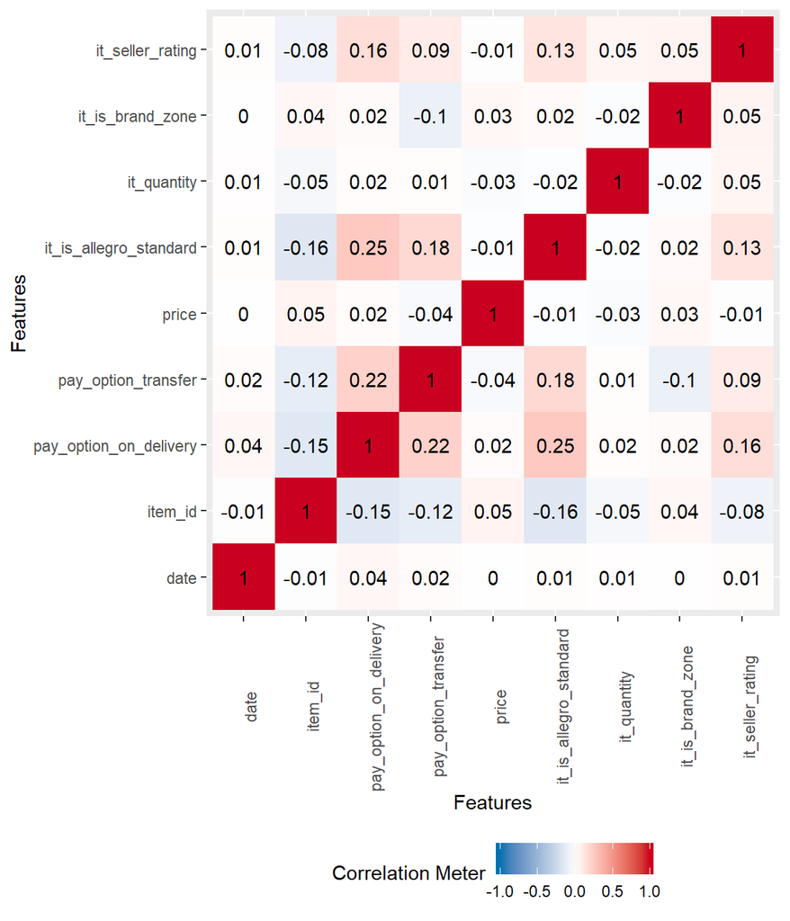

```r
temp <- data
temp$date <- as.numeric(temp$date)
plot_correlation(temp, maxcat = 10L)
```

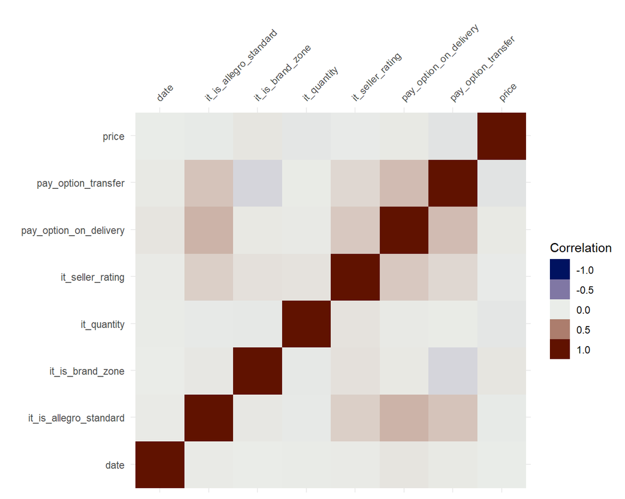

```r
vis_cor(select(temp,date,it_seller_rating,it_is_brand_zone,it_quantity, it_is_allegro_standard,price,pay_option_transfer,pay_option_on_delivery))
```

Wydaje mi się, że DataExplorer lepiej poradził sobie z plotem korelacji niż visDat.

# 5 Pozostałe

Ktoś postanowił kupić nieruchomość przed północą i nikt nie kupił biletów w nocy.

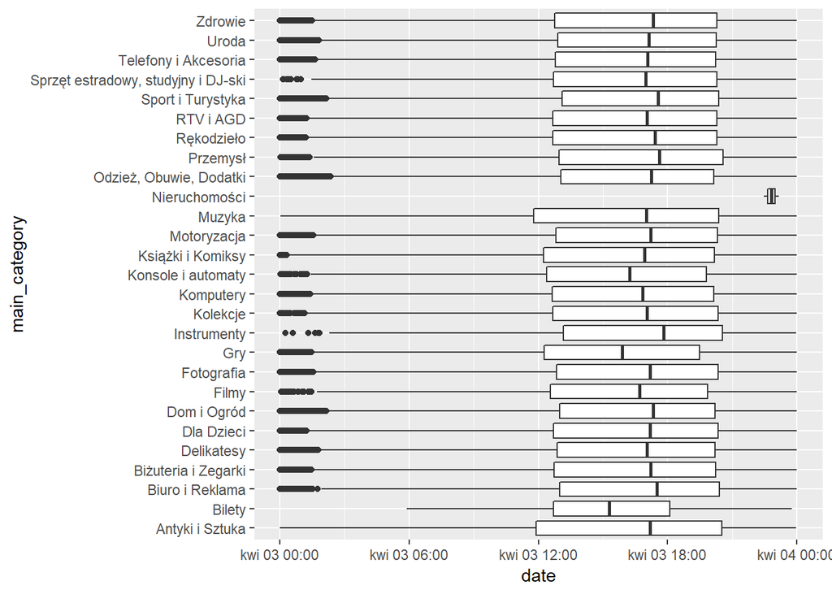

```r
ggplot(data, aes(x=main_category, y=date)) + geom_boxplot() + coord_flip()
```

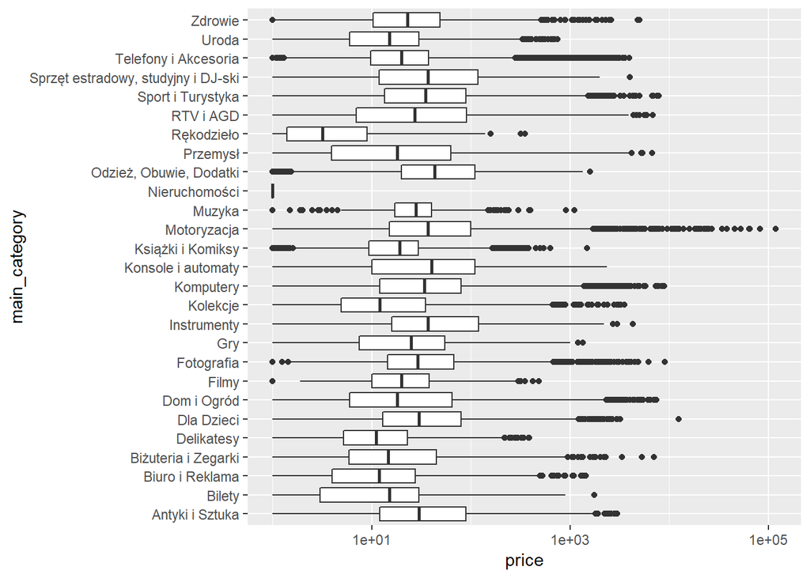

```r
ggplot(data, aes(x=main_category, y=price)) + geom_boxplot() + coord_flip() + scale_y_log10()
```

# 6 Podsumowanie

Ogólnie w każdym z pakietów można znaleźć przydatne funkcje, które szybko i sensownie zrobią za nas dużą część pracy. Łatwo w ten sposób znaleźć liczby opisujące cały zbiór danych, rozkłady zmiennych, czy korelacje. Jeżeli chcemy dowiedzieć się czegoś szczególnego, to pozostaje nam napisanie własnego kodu.